# Population Mean Skew

Nick O’Brien

29/04/2020

## Introduction

A Script for testing how population mean distributions over 100 runs can vary in skew when not normal, based on the effects of drift under SLiM. This model uses deleterious mutation prevalence of 1 in 10 neutral mutations, 0.5 recombination between loci (unlinked) and N = 100. This was previously tested to show a non-normal distribution; if the resulting shape of the distribution of means is due to the random effects of drift, we would expect that between runs of the same model, the distributions would differ, and average out to normal The idea is to run this multiple times from r for different seed sets to observe the change in skew due to random drift when looking atdistributions of means from a seed set at the final generation (where variance should be at its greatest under Brownian motion)

## Getting distributions 100 seeds at a time

We shuffle the output so we can grab an independent sample of 100 runs at a time, and then compare each of those samples to see if the skew of their distributions differs.

```r
# Shuffle final output so we can sample from it 100 seeds at a time, creating a new shapiro p value matrix from
# each 100 seeds

shuffled_final<- sample(slim_out_multiNe100_delmu0.1_r0.5_final)
seqshap <- as.integer(seq(100, 1000, by = 100))

library(fitdistrplus) # library for fitdist and denscomp
```

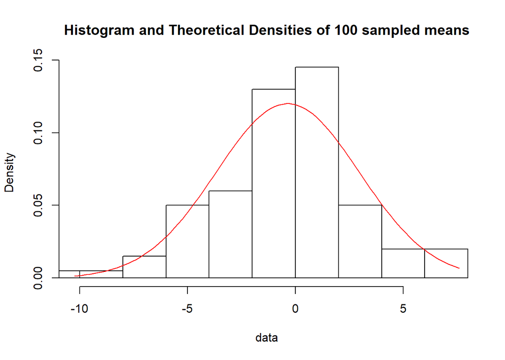

```
##
##  Shapiro-Wilk normality test
##
## data:  sample_temp
## W = 0.98441, p-value = 0.2875
```

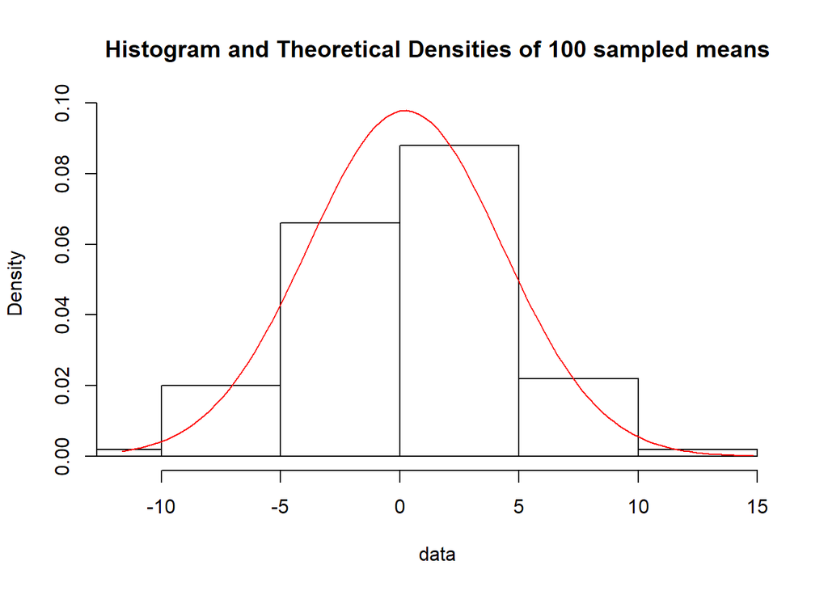

```
##
##  Shapiro-Wilk normality test
##
## data:  sample_temp
## W = 0.98262, p-value = 0.2116
```

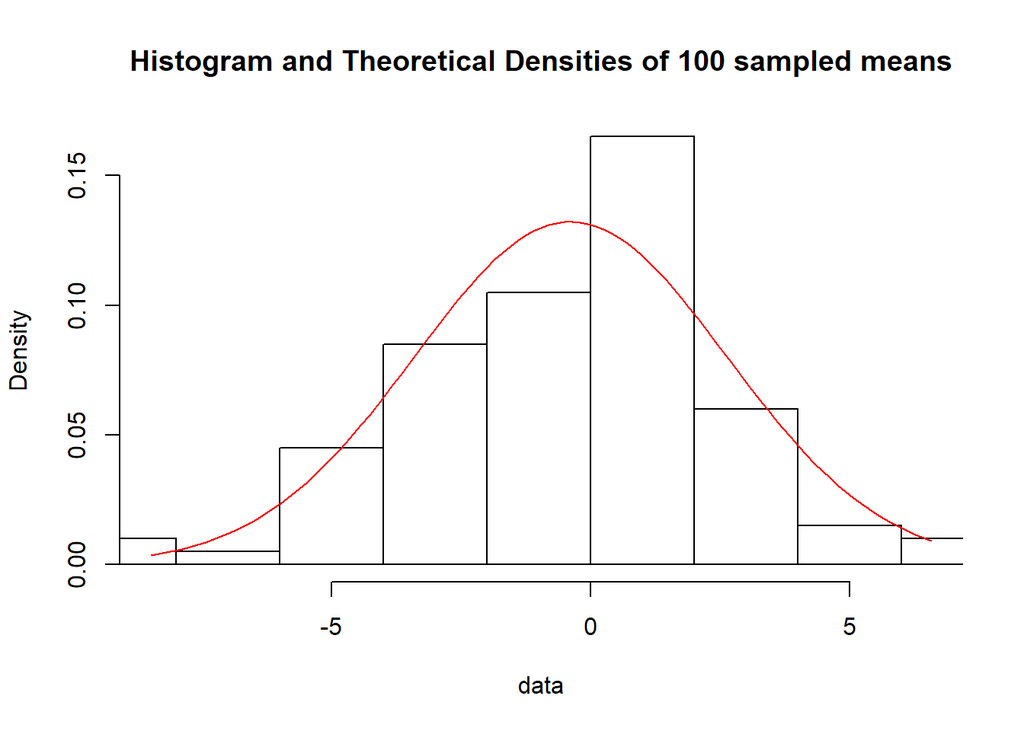

```
##
##  Shapiro-Wilk normality test
##
## data:  sample_temp
## W = 0.97482, p-value = 0.05221
```

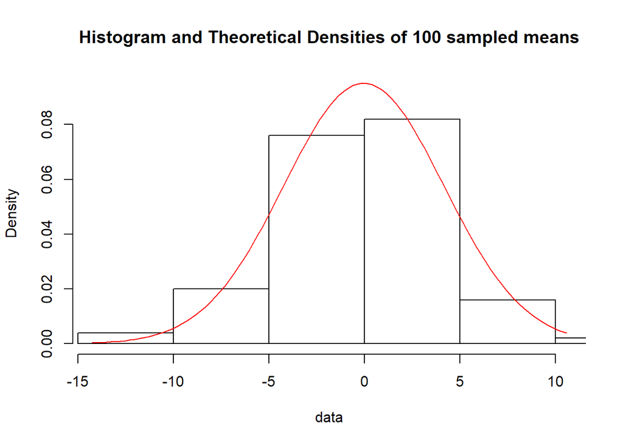

```
##
##  Shapiro-Wilk normality test
##
## data:  sample_temp
## W = 0.98328, p-value = 0.2373
```

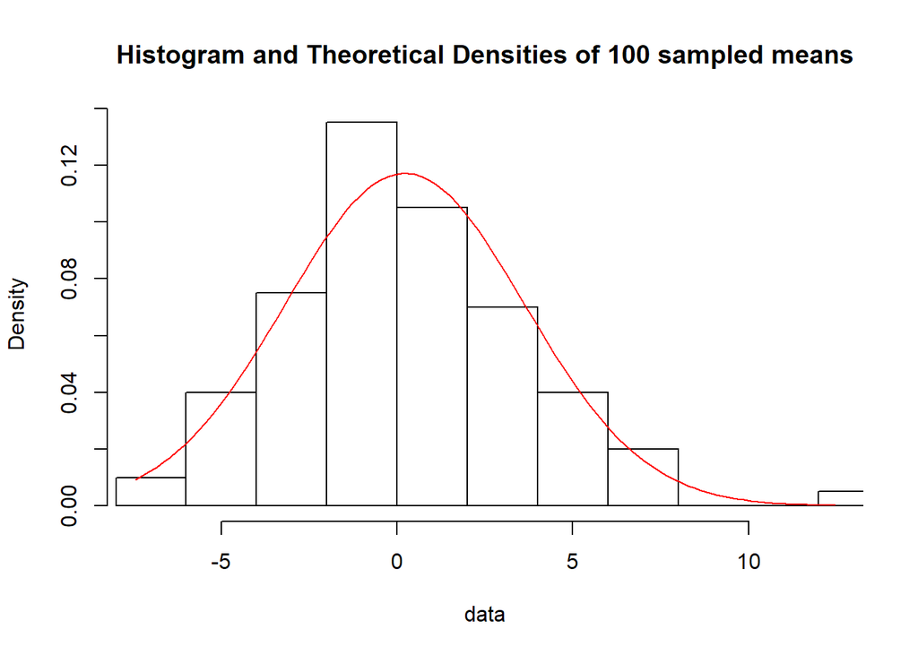

```
##
##  Shapiro-Wilk normality test
##
## data:  sample_temp
## W = 0.98255, p-value = 0.2089
```

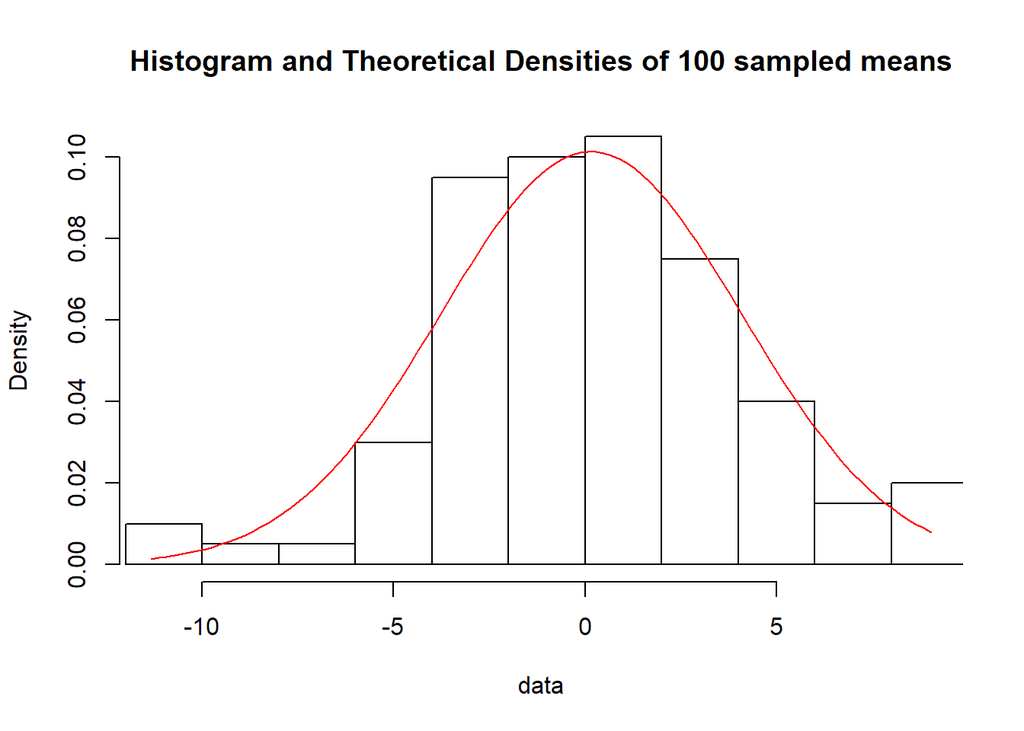

```
##
##  Shapiro-Wilk normality test
##
## data:  sample_temp
## W = 0.98736, p-value = 0.4621
```

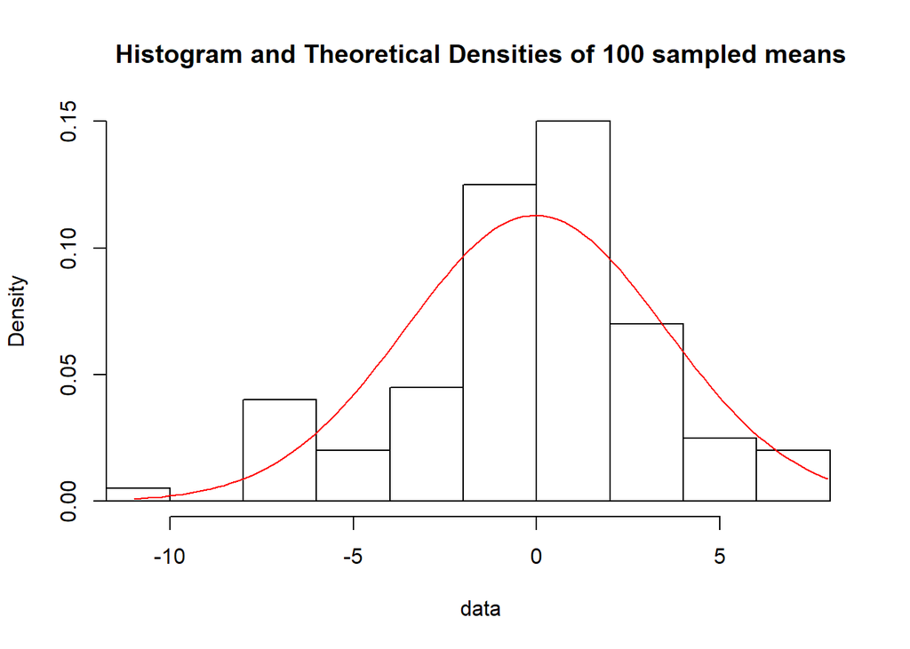

```
##
##  Shapiro-Wilk normality test
##
## data:  sample_temp
## W = 0.96334, p-value = 0.007012
```

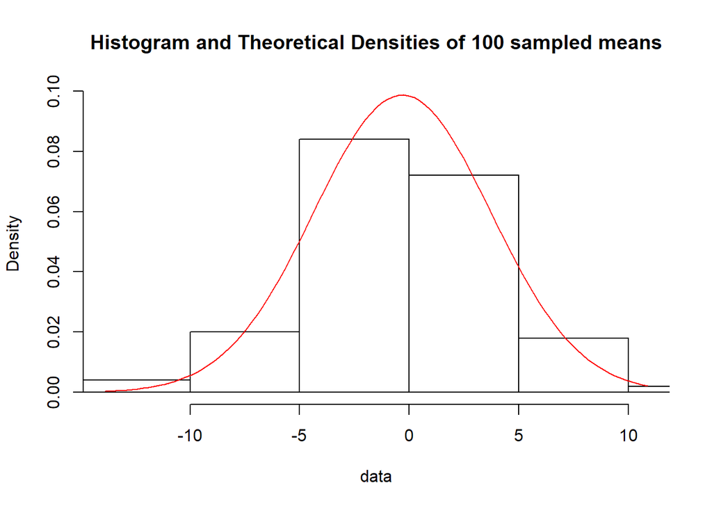

```
##
##  Shapiro-Wilk normality test
##
## data:  sample_temp
## W = 0.98021, p-value = 0.1379
```

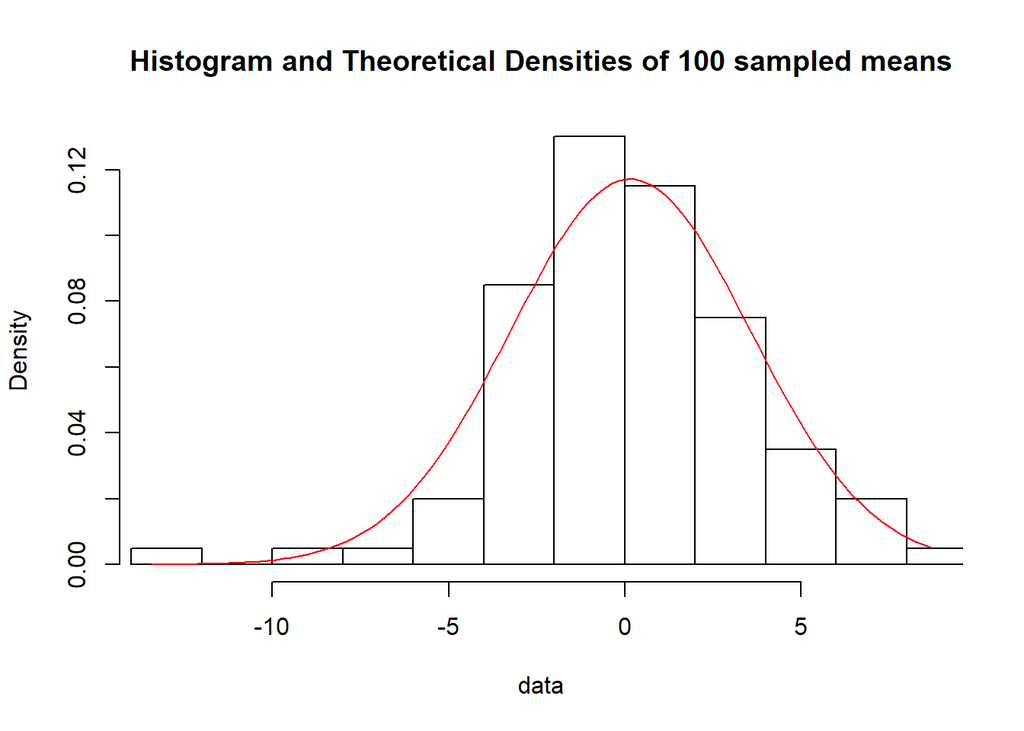

```
##
##  Shapiro-Wilk normality test
##
## data:  sample_temp
## W = 0.97178, p-value = 0.03028
```

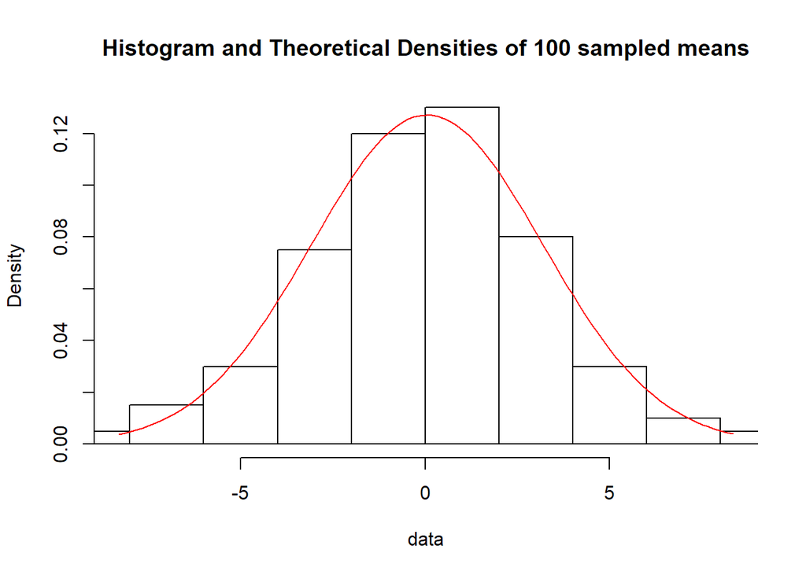

```
##
##  Shapiro-Wilk normality test
##
## data:  sample_temp
## W = 0.99573, p-value = 0.9896
```

```r
for (s in 1:length(seqshap)) {

      # Graph
      sample_temp <- shuffled_final$mean[(seqshap[s]-99):seqshap[s]]
      fit_sampled <- fitdist(sample_temp, "norm")
      denscomp(fit_sampled, addlegend = F, main = "Histogram and Theoretical Densities of 100 sampled means")

      #Associated Shapiro test
      print(shapiro.test(sample_temp))

    }
```

## Conclusions

As we can see from these figures, the skewing does change, and interestingly, it is normal some of the time - indicating that drift is having an effect on the distribution. Summing all of these leads to this total distribution:

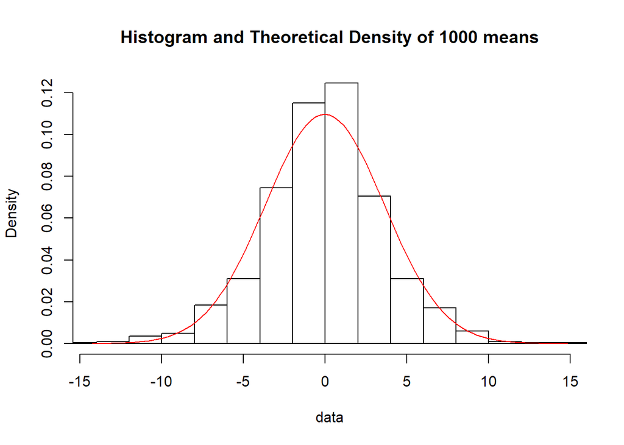

```r
fit <- fitdist(shuffled_final$mean, "norm")
denscomp(fit, addlegend = F, main = "Histogram and Theoretical Density of 1000 means")
```

```r
#Associated Shapiro test
print(shapiro.test(shuffled_final$mean))
```

```
##
##  Shapiro-Wilk normality test
##
## data:  shuffled_final$mean
## W = 0.9891, p-value = 8.982e-07
```